# Des Moines Data

Hunter Rose

```r
polk_crash_data = read.csv('Polk_County_Data.csv')
polk_vehicle_data = read.csv('Polk_County_Vehicle_Data.csv')
```

```r
polk_crash_data = polk_crash_data %>%
    mutate(CRASH_DATE = as_datetime(as.character(CRASH_DATE)),
        LITERAL = as.character(LITERAL),
        DRUGALC = factor(DRUGALC, levels=rev(c('None Indicated', 'Refused',
            'Alcohol (<Statutory)', 'Drug/Alcohol (< Statutory)',
            'Drug',
            'Alcohol (Statutory)', 'Drug/Alcohol (Statutory)',
            'Under Influence of Alcohol/Drugs/Medications'))))


weather = c('Blowing sand, soil, dirt', 'Blowing Snow', 'Clear', 'Cloudy', 'Fog, smoke, smog',
            'Freezing rain/drizzle', 'Rain', 'Severe Winds', 'Sleet, hail', 'Snow')
levels(polk_crash_data$WEATHER)[!levels(polk_crash_data$WEATHER) %in% weather] = NA
surface = c('Dry', 'Gravel', 'Ice/frost', 'Mud, dirt', 'Oil', 'Sand', 'Slush', 'Snow', 'Wet')
levels(polk_vehicle_data$CSURFCOND)[!levels(polk_vehicle_data$CSURFCOND) %in% surface] = NA

polk_crash_data = polk_crash_data %>%
  filter(X > -94 & X < -93 & Y < 42 & Y > 41.3)
polk_vehicle_data = polk_vehicle_data %>%
  filter(X > -94 & X < -93 & Y < 42 & Y > 41.3)
```

```r
str(polk_vehicle_data)
```

```
## 'data.frame':    211014 obs. of  7 variables:
##  $ X         : num  -93.7 -93.7 -93.8 -93.8 -93.8 ...
##  $ Y         : num  41.6 41.6 41.7 41.7 41.6 ...
##  $ DRIVERAGE : int  99 17 34 67 46 52 57 25 27 35 ...
##  $ DRIVERGEN : Factor w/ 4 levels "Female","Male",..: 3 2 1 2 2 2 2 1 1 2 ...
##  $ SPEEDLIMIT: Factor w/ 17 levels "1","10 MPH","15 MPH",..: 5 5 7 7 7 7 5 5 15 15 ...
##  $ CSURFCOND : Factor w/ 9 levels "Dry","Gravel",..: 1 1 1 1 1 1 4 4 3 8 ...
##  $ FATALITIES: int  0 0 0 0 0 0 0 0 0 0 ...
```

```r
str(polk_crash_data)
```

```
## 'data.frame':    109509 obs. of  28 variables:
##  $ X.1                      : int  1 2 3 4 5 6 7 8 9 10 ...
##  $ X                        : num  -93.7 -93.6 -93.6 -93.6 -93.6 ...
##  $ Y                        : num  41.6 41.7 41.6 41.6 41.6 ...
##  $ CRASH_KEY                : int  2009001001 2009001746 2009001775 2009001095 2009001130 2009001790 2009003268 2009002601 2009003306 2009002645 ...
##  $ CRASH_DATE               : POSIXct, format: "2009-01-12" "2009-01-09" ...
##  $ CRASH_MONTH              : Factor w/ 12 levels "April","August",..: 5 5 5 5 5 5 5 5 5 5 ...
##  $ CRASH_DAY                : Factor w/ 7 levels "Friday","Monday",..: 2 1 7 3 4 5 7 7 5 1 ...
##  $ TIMESTR                  : Factor w/ 1440 levels "0:00","0:01",..: 1440 676 196 1363 305 1356 1256 1406 591 887 ...
##  $ DISTRICT                 : int  1 1 1 1 1 1 1 1 1 1 ...
##  $ COUNTY_NUMBER            : int  77 77 77 77 77 77 77 77 77 77 ...
##  $ CITY_NUMBER              : logi  NA NA NA NA NA NA ...
##  $ LITERAL                  : chr  "I-235" "E 1ST ST & SE DELAWARE AVE & NE DELAWARE AVE" "US 6/E EUCLID AVE & DIXON ST" "ARTHUR AVE" ...
##  $ DRUGALC                  : Factor w/ 8 levels "Under Influence of Alcohol/Drugs/Medications",..: 8 8 8 8 8 8 8 8 8 8 ...
##  $ CSRFCND                  : Factor w/ 13 levels "Dry","Gravel",..: 10 10 3 3 3 1 10 3 13 10 ...
##  $ WEATHER                  : Factor w/ 10 levels "Blowing sand, soil, dirt",..: 10 10 10 4 3 3 3 1 3 1 ...
##  $ RCNTCRC                  : Factor w/ 17 levels "Debris","Disabled vehicle",..: 11 11 11 4 4 4 11 11 10 4 ...
##  $ FATALITIES               : int  0 0 0 0 0 0 0 0 0 0 ...
##  $ INJURIES                 : int  1 1 1 0 0 0 0 0 0 1 ...
##  $ VEHICLES                 : int  2 2 2 2 3 1 2 2 2 2 ...
##  $ TOCCUPANTS               : int  3 2 3 2 1 2 3 2 5 5 ...
##  $ REST_UPDATED             : Factor w/ 3 levels "2020-02-20T16:00:13.245Z",..: 1 1 1 1 1 1 1 1 1 1 ...
##  $ REST_UPDATE_UTC_OFFSET   : logi  NA NA NA NA NA NA ...
##  $ CRASH_DATETIME           : logi  NA NA NA NA NA NA ...
##  $ CRASH_DATETIME_UTC       : logi  NA NA NA NA NA NA ...
##  $ CRASH_DATETIME_UTC_OFFSET: logi  NA NA NA NA NA NA ...
##  $ CITY_NAME                : logi  NA NA NA NA NA NA ...
##  $ COUNTY_NAME              : logi  NA NA NA NA NA NA ...
##  $ CARDINAL                 : logi  NA NA NA NA NA NA ...
```

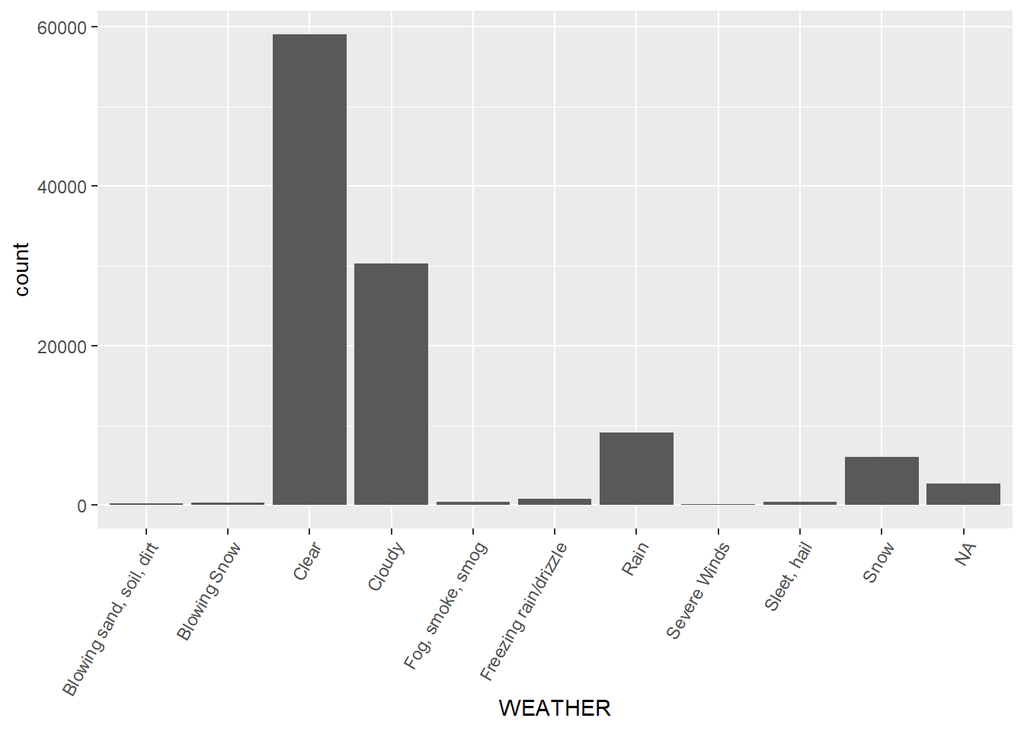

```r
polk_crash_data %>%
  ggplot(aes(WEATHER)) + geom_bar() + theme(axis.text.x = element_text(angle=60, hjust = 1))
```

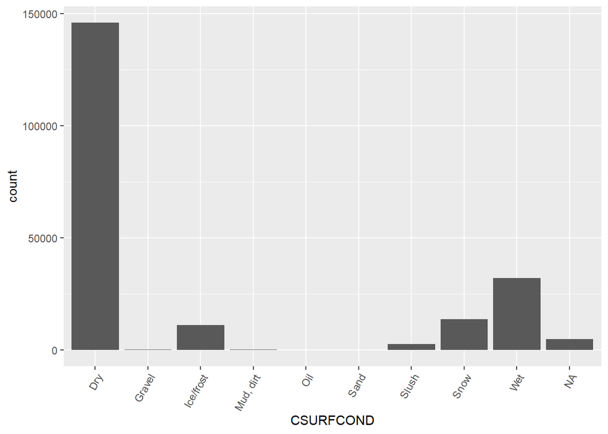

```r
polk_vehicle_data %>%
  ggplot(aes(CSURFCOND)) + geom_bar() + theme(axis.text.x = element_text(angle=60, hjust = 1))
```

After looking at the Weather graph, we can see that around 90,000 of crashes occur during clear/cloudy conditions. This was somewhat surprising to see such high occurences with conditions that aren’t difficult to drive in. Rain and snow both combine for around 17,000 crashes, a small comparison to clear/cloudy. When looking at surface conditions, we can see that most crashes are on dry concrete. We see wet conditions being the next largest category, with snow and ice/frost making up the third spot. I thought that we would see more crashes with bad conditions, but it could be because people tend to stay off the roads when there is bad weather.

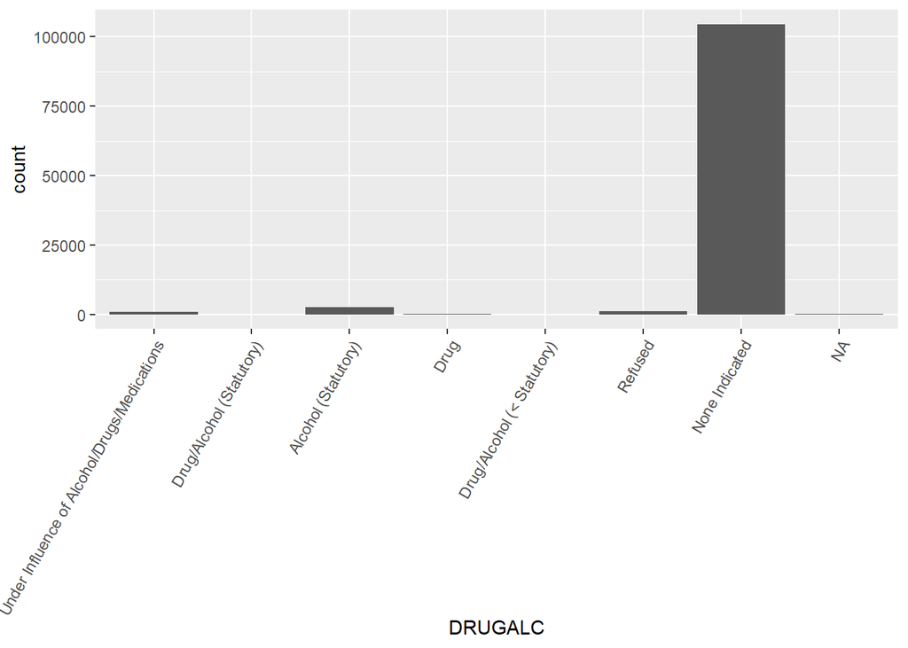

```r
polk_crash_data %>%
  ggplot(aes(DRUGALC)) + geom_bar() + theme(axis.text.x = element_text(angle=60, hjust = 1))
```

```r
levels(polk_crash_data$DRUGALC)
```

```
## [1] "Under Influence of Alcohol/Drugs/Medications"
## [2] "Drug/Alcohol (Statutory)"
## [3] "Alcohol (Statutory)"
## [4] "Drug"
## [5] "Drug/Alcohol (< Statutory)"
## [6] "Alcohol (<Statutory)"
## [7] "Refused"
## [8] "None Indicated"
```

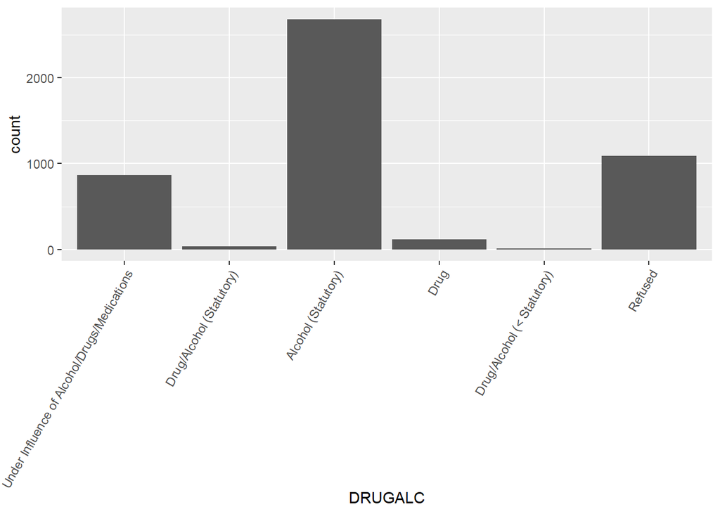

```r
drug_alc = c('Under Influence of Alcohol/Drugs/Medications', 'Drug/Alcohol (Statutory)', 'Alcohol (Statutory)',
             'Drug', 'Drug/Alcohol (< Statutory)', 'Alcohol (<Statutory)', 'Refused')
levels(polk_crash_data$DRUGALC)[!levels(polk_crash_data$DRUGALC) %in% drug_alc] = NA

polk_crash_data %>%
  select(DRUGALC) %>%
  drop_na(DRUGALC) %>%
  ggplot(aes(DRUGALC)) + geom_bar() + theme(axis.text.x = element_text(angle=60, hjust = 1))
```

At first glance into the drugs/alcohol category, we can see that the majority of the crashes indicated there was no substances involved. After removing this level, we can get a better look at those driving under the influence. Once filtered, the majority of crashes that involved substances was alcohol. An interesting category to look at in this graph is those that refused to take a test. Depending on the crash evidence, refusing to take a breathalyzer can get you out of a DUI. It can also get you into more trouble and long-term issues such as suspended license or jail time. So to refuse a test is sort of a gamble when it comes to the law.

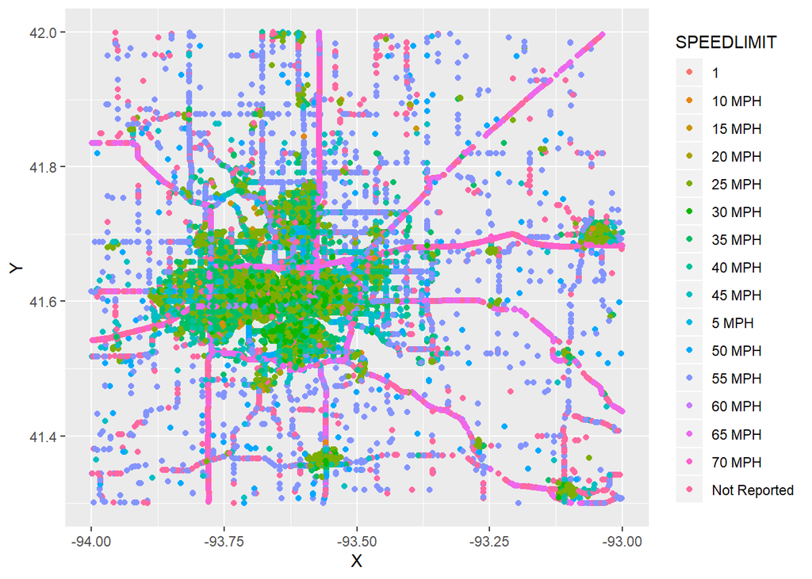

```r
polk_vehicle_data %>%
  group_by(SPEEDLIMIT) %>%
  ggplot(aes(x=X, y=Y, color=SPEEDLIMIT)) + geom_point()
```

When looking at this plot, we can start to see where the highways are and where the more residential areas are.

```r
des_map <- get_map(getbb("Des Moines"))
```

[figure not shown]

```r
fatal <- polk_vehicle_data %>%
  filter(FATALITIES > 0) %>%
  group_by(FATALITIES)


ggmap(des_map) + geom_point(data = fatal, aes(x=X, y=Y, color=FATALITIES))
```

When there are fatalities in a crash, we can see that most of them are only one person. There are some places that have some type of consistency for crashes that lead to fatalities, those around the interstate on/off ramp, along with those around 2nd Ave.

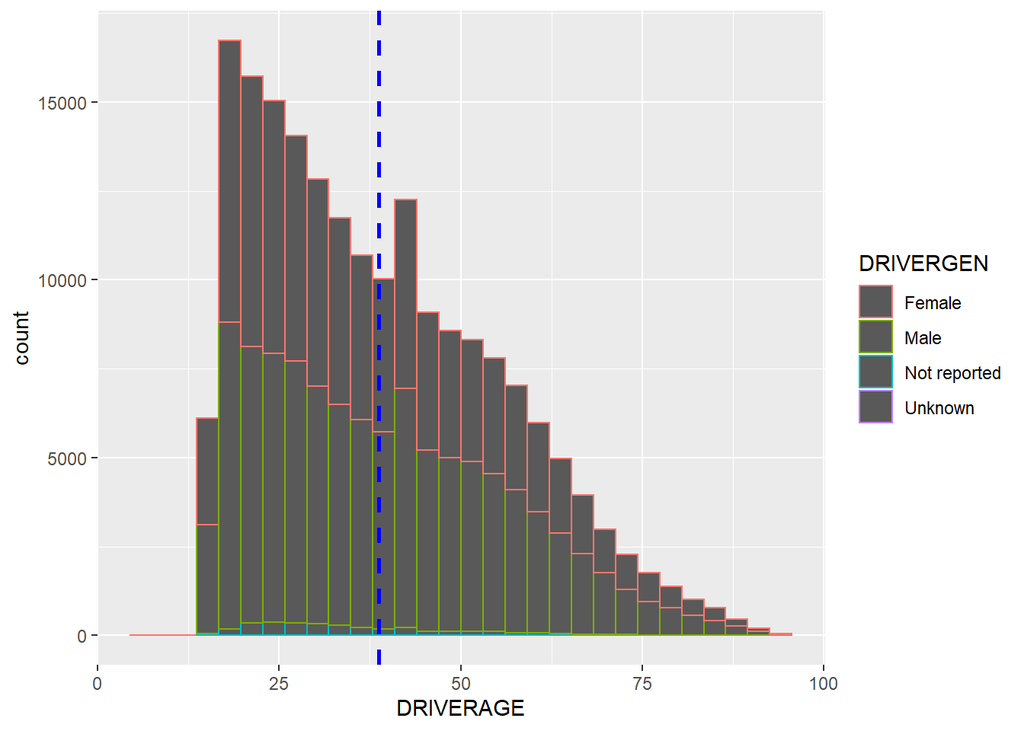

```r
polk_vehicle_data %>%
  group_by(DRIVERAGE) %>%
  filter(DRIVERAGE < 95) %>%
  ggplot(aes(x=DRIVERAGE, color=DRIVERGEN)) + geom_histogram() + geom_vline(aes(xintercept=mean(DRIVERAGE)), color = "blue", linetype="dashed", size=1)
```

This graph has shown that the average age of the person causing the crash is around 38 years. We also see a very high amount of crash in the 16-23 years range, with a steady decrease in crashes per age as age increases outside of around the 43 mark. As far as gender goes, we can see that there is a slight majority of males than females.

```r
streets = polk_crash_data %>% mutate(total=X*X+Y*Y)

scnt = streets %>%
    group_by(total) %>%
    summarize(count = n())

streets = streets %>%
    left_join(scnt, by='total') %>%
    arrange(desc(count))

str(streets %>% distinct(LITERAL, .keep_all=TRUE))
```

```
## 'data.frame':    7998 obs. of  30 variables:
##  $ X.1                      : int  87 204 513 25 35 24 70 658 1885 216 ...
##  $ X                        : num  -93.6 -93.6 -93.6 -93.6 -93.6 ...
##  $ Y                        : num  41.7 41.6 41.6 41.6 41.6 ...
##  $ CRASH_KEY                : int  2009010029 2009049026 2009032753 2009003866 2009005335 2009003865 2009007522 2010020428 2009047012 2009051421 ...
##  $ CRASH_DATE               : POSIXct, format: "2009-02-21" "2009-12-07" ...
##  $ CRASH_MONTH              : Factor w/ 12 levels "April","August",..: 4 3 2 5 5 5 4 9 10 3 ...
##  $ CRASH_DAY                : Factor w/ 7 levels "Friday","Monday",..: 3 2 7 4 1 4 6 1 1 4 ...
##  $ TIMESTR                  : Factor w/ 1440 levels "0:00","0:01",..: 181 7 595 382 802 386 429 552 638 714 ...
##  $ DISTRICT                 : int  1 1 1 1 1 1 1 1 1 1 ...
##  $ COUNTY_NUMBER            : int  77 77 77 77 77 77 77 77 77 77 ...
##  $ CITY_NUMBER              : logi  NA NA NA NA NA NA ...
##  $ LITERAL                  : chr  "US 69/S ANKENY BLVD/N ANKENY BLVD & W 1ST ST & E 1ST ST" "US 69/SE 14TH ST & E PARK AVE" "US 69/SE 14TH ST & MAURY ST" "IA 163/E UNIVERSITY AVE & E 30TH ST" ...
##  $ DRUGALC                  : Factor w/ 7 levels "Under Influence of Alcohol/Drugs/Medications",..: NA NA NA NA NA NA NA NA NA NA ...
##  $ CSRFCND                  : Factor w/ 13 levels "Dry","Gravel",..: 1 10 13 10 1 10 1 1 1 10 ...
```

[output cut: 16 more lines]

[figure not shown]

```r
topstreets = streets %>%
    distinct(total, .keep_all=TRUE) %>%
    distinct(LITERAL, .keep_all=TRUE) %>%
    filter(LITERAL %in% head(LITERAL, 10))

des_map <- get_map(getbb("Des Moines"))

ggmap(des_map) + geom_point(data = topstreets, aes(x=X, y=Y, color=count)) +
  geom_text(data = topstreets, aes(x=X, y=Y, label = LITERAL), hjust=1, vjust=0, size=3, angle=20)
```